# Does Money in the MLB Matter?

### Group members

Junhak Lee, **Daniel Gunther** , Kara Conrad, Yikai Zhang Group: C

### Introduction:

There is a lot of money in baseball. Teams in the MLB are worth on average $2.2 billion dollars and players are currently being paid up to $37 million dollars a year. MLB teams are like any company: they aim to maximize their profits by taking risks and investing in capital. In sports, the most important investment is the players that make up the team. Organizations hope that better players lead to more merchandise sold and more importantly, more games won.

Our goal is to determine if MLB teams are paying their most productive players, and if this is true, does it follow that higher paid teams win more games. We aim to look at this at the individual and team level:

On the individual level our target question is: Do players in the MLB with better hitting statistics have higher salaries?

On the team level our target question is: Do teams with a higher average salary win more games?

### Background

Our goal is to analyze how much salary affects results in the MLB. A player’s batting status mostly depends on one statistic called OPS (described below) and players with better statistics often receive higher salaries. So, we aim to do this by answering the questions: “do higher paid individuals in the MLB have better hitting statistics?” and, “do teams with a higher average salary win more games than teams with a lower average salary?”. Using salary data originally scraped from Sportrac, a large online sports team, & player contract resource, of the top 26 players per MLB team’s, from 2019 to 2020, we compare their salaries to their batter’s statistics collected by Baseball-Reference, a sponsored database from 1901 to 2021 and ESPN fantasy, which we will use data from just 2019 to 2020. There are several statistics amongst the two batter’s datasets that we will use for the project which are OPS, OBP and SLG. We will describe these ones below. All three sets are posted on Kaggle where our team found them.

There are several terms we should define for those who lack baseball knowledge. Most readers may not know what slugging (SLG), OBP, and OPS are. A player’s SLG percentage represents the total number of bases a player records per at-bat, which is calculated as total bases divided by at bats. A score of around .450 is very good. Second, OBP stands for on-base percentage: of all their hits, what percent of the time does the player make it onto a base. Third, OPS is “On-base Plus Slugging,” As its word says, OPS is a statistic that adds up batter’s OBP and SLG percentage to calculate the scoring productivity of batters. A score of .9000 and higher is considered excellent.

We will be filtering out players that do not have the average number of at-bats in the 2019 season. We hope this will remove outliers such as a low paid athlete that has one at bat and got a lucky hit.

Key Variables from the MLB Dataset (post cleaning and manipulation)

| Name | Description |
| --- | --- |
| Player | The player’s name |
| Year | The year |
| Wins | Numbers of Games Team Won in 2019 Season |
| Salaries | The annual salaries for a certain player |
| OPS | On-base Plus Slugging, which is the summation of OBP and SLG |
| OBP | On-base Percentage |
| SLG | Slugging average |

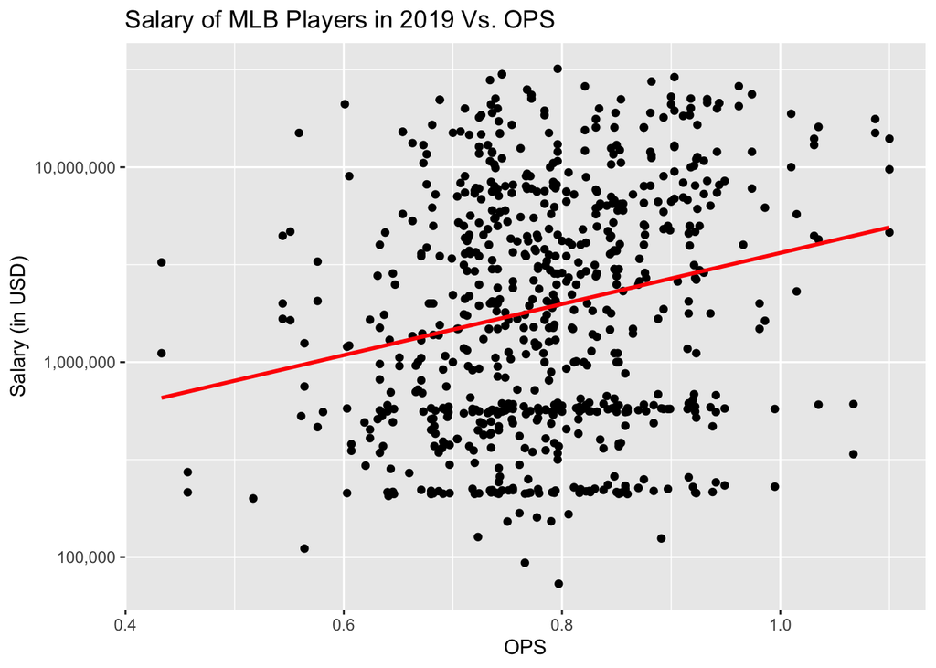

**OPS Vs. Individual’s Salary:** Each dot represents a MLB player who had at least the average number of at-bats in the 2019 regular season. They are placed on the graph based on their salary and OPS for the 2019 regular season. The red line shows a slightly positive linear model with a lot of variance above and below it.

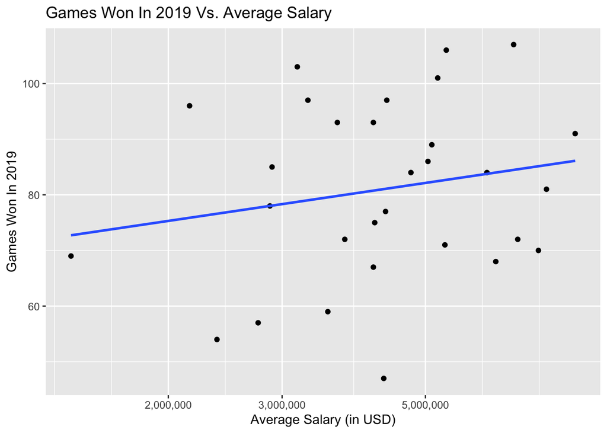

**Games Won In 2019 Vs. Average Salary** Each dot is a team in the MLB placed by the average salary they pay their players and the number of games they won in the 2019 regular season. The blue line shows a slightly positive linear model with large variance above and below it.

### Analysis

**Analysis at the Individual Level:** We do see that as OPS increases, there is generally an increase in the salary of the batter. We found a p-value of $2.74 \times 10^{-8} (t = 5.621, df = 705)$ between ops and salary. This is less than $\alpha = 0.05$ so the relationship between these variables is significant. The 95% confidence interval of the slopes is between $8,044,146$ USD and $16,680,038$ USD which means that for every 1 point increase in OPS, the players gets paid an additional salary within the interval. The small p-value and this confidence interval means that the true difference in means is not equal to 0, so we can consider that the alternative hypothesis is correct and that increase in OPS leads to an increase in salary. However, we found an R-squared value of 0.04154 which shows that the positive relationship between these variables is extremely weak and the model does not fit the data well. Therefore, we cannot definitely conclude that increase in OPS leads to higher salary.

**Analysis at the Team Level:** We did not find a significant relationship between the average salary of a team and the number of games they won as the p-value found was 0.363 (much above alpha of 0.05). This large p-value forces us to accept the null hypothesis in that an increase in average salary for MLB teams does not explain an increase in wins. In addition, the slope we found was $1.556 \times 10^{-6} (t = 0.924, df = 28)$. This is very close to zero and we know that a horizontal line shows that as one variable increases, the other is unaffected, showing one variable in independent of the other. This further concludes that the increase in average salary for an MLB team does not effect the amount of wins they get in the regular season.

### Discussion

1. Our data is solely based on the 2019 regular season (the only data we could find that had batter salary, ops, team, etc.). There is a chance that this season was different than most, and other years would yield different results. 2019 was a year with more rookies than usual; this can skew our data because if there is a strong rookie core, then there are a bunch of players who hit well but don’t get paid as much (but would get paid more in future years).
2. It is also possible that our hypothesis failed because one of our other assumptions failed. These assumptions include that there were no ties (ties are extremely rare in baseball), the small number of players that didn’t have an OPS reported would not changed the results too much, and that the pitching core for each team was even across the league.
3. The final, and most likely reason, is that we did not choose (or had access to in our data set) the correct variables that would explain an increase in salary or an increase in the number of games won. Our hypothesis was just wrong, and we likely boiled down salary and games won to a too simple and naively obvious choice of factors.

### References

1st data set = https://www.kaggle.com/kaito510/mlb-player-salaries –> salaries of MLB players

2nd data set = https://www.kaggle.com/darinhawley/mlb-batting-stats-by-game-19012021 –> batter’s stats and team wins (1901 - 2021)

3rd data set = https://www.kaggle.com/mur418/mlb-2019-player-stats-and-2020-player-projections –> player’s batting stats in 2019 season

https://en.wikipedia.org/wiki/On-base_plus_slugging –> Gave in depth definition OPS and gave testimony to the fact that hitters are considered excellent if they have >= 0.9000 OPS

https://baseballtrainingworld.com/how-many-at-bats-do-mlb-players-get-in-a-season/ –> Average at bats per season is around 200 so we are filtering out batters with less than this to remove outliers